# **Using Data Science to Analyze Temperature Change Across the Globe**

## Introduction

Since the start of the Industrial Revolution in 1760, hummanity has enjoyed unprecented levels of productivity and efficiency. While the rise of large-scale industry has its benefits, many have also recognized its devastating side effects. Chief among them is global warming, which is the phenomenon of increasing average temperatures of the Earth's atmosphere. Many researchers have concluded that global warming is disastrous to the Earth's ecosystem and will eventually cause irreversible damage to the planet. Even though this climate crisis is global, its impact may not be equally severe in different parts of the world. As such, understanding the effects of global warming in different regions of the globe is important to better prepare for and prevent environmental disasters in those areas.

The purpose of this tutorial, then, is to examine the changes in temperature over time based on location through data science. By the end, I hope to provide insights into the Data Science Pipeline, demonstrate that our planet is indeed becoming warmer, and create models to predict future temperature changes based on location.

## Data Collection

The first part of the data lifecycle is collecting data and obtaining a useful dataset. Sometimes the data is already collected and can be used as is. Other times, you may need to collect data from websites via [scraping](https://www.edureka.co/blog/web-scraping-with-python/) , which is process of extracting information from a website. The [dataset I am using](https://www.kaggle.com/datasets/berkeleyearth/climate-change-earth-surface-temperature-data) comes from kaggle.com and is hosted on GitHub to make them publicly accessible. Important technologies used: [pandas](https://pandas.pydata.org/pandas-docs/stable/).

```python
import pandas as pd

# Create DataFrame by reading a csv file
df = pd.read_csv("https://raw.githubusercontent.com/wwei4949/datasets/main/GlobalTemperaturesByMajorCity.csv")
df.head()
```

|  | dt | AverageTemperature | City | Country | Latitude | Longitude |
| --- | --- | --- | --- | --- | --- | --- |
| 0 | 1849-01-01 | 26.704 | Abidjan | Côte D'Ivoire | 5.63N | 3.23W |
| 1 | 1849-02-01 | 27.434 | Abidjan | Côte D'Ivoire | 5.63N | 3.23W |
| 2 | 1849-03-01 | 28.101 | Abidjan | Côte D'Ivoire | 5.63N | 3.23W |
| 3 | 1849-04-01 | 26.140 | Abidjan | Côte D'Ivoire | 5.63N | 3.23W |
| 4 | 1849-05-01 | 25.427 | Abidjan | Côte D'Ivoire | 5.63N | 3.23W |

At this point, our data set is organized as tabular data and we can make some basic observations. This includes what variables there are and what the values generally look like. Based on the source of the dataset and what we can observe, our dataset provides the average land temperatures of major cities for each month over many years. The column names should be self explanatory.

Let's also see what the dimensionality of our dataset is.

```python
df.shape
```

```
(239177, 6)
```

So, there are 239177 data points and 6 variables in total.

## Data Management

After we have the dataset, we want to make sure that the data is useful for analysis. In this second part of the data lifecycle, we clean and organinze our data. Note that datasets are very diverse and this process can vary significantly depending on your raw data. The processes below are only representative of how this particular dataset needs to be modified to fit our purposes. You can learn more about data management [here](https://infoguides.gmu.edu/learn_python/pandas). Important technologies used: [NumPy](https://numpy.org/doc/stable/).

First we want to determine if there are missing values in the dataset.

```python
# Count number of missing values in each column
df.isnull().sum()
```

```
dt                        0
AverageTemperature    11002
City                      0
Country                   0
Latitude                  0
Longitude                 0
dtype: int64
```

We see that there are 11002 rows where AverageTemperature values are missing. This is less than 5% of our overall data, which is not a significant amount. As such, we can simply remove all of the data points associated with the missing values. Having missing values in dependent variables means that the data point will contribute little to our data analysis. However, we still lose parts of our dataset. There are also other ways to deal with missing data, which you can find [here](https://cmsc320.github.io/2022spring/lecs/cmsc320_spr2022_lec12+13.pdf).

```python
# Remove all rows with missing values
df.dropna(axis=0, how="any", inplace=True)
df = df.reset_index(drop=True)

df.shape
```

```
(228175, 6)
```

Before we go any further, it is helpful to know what types of data are in each column.

```python
df.dtypes
```

```
dt                     object
AverageTemperature    float64
City                   object
Country                object
Latitude               object
Longitude              object
dtype: object
```

From this, we learn how the values will be affected by the operations we will perform on them. Furthermore, we can identify if any column needs to converted into a more useful data type.

We also have to make sure that our data is tidy. Tidying the dataset we have is simple since it already fulfills the 3 criteria: each observation is in a row, each variable is a column, and each type of observational unit forms a table. You can learn more about tidy data [here](https://byuidatascience.github.io/python4ds/tidy-data.html). Based on our observations about the types of data in each column, we also make appropriate modifications. Moreover, you can clean the dataset and reduce noise by dropping variables that are not pertinent to this project.

```python
import numpy as np

# Convert our date values into datetime objects
df["dt"] = pd.to_datetime(df.dt)
# Change the column names to more understandable ones
df.rename(columns={"dt":"Date"}, inplace=True)

# Convert Latitude and Longitude column into floats
# Note that West(W) and South(S) indicate negative values
df["Latitude"] = np.where(df["Latitude"].str.find("S") != -1, "-" + df["Latitude"], df["Latitude"])
df["Longitude"] = np.where(df["Longitude"].str.find("W") != -1, "-" + df["Longitude"], df["Longitude"])

# We extract only the numerical part and convert it o float
df["Latitude"] = df["Latitude"].str.extract('(-?\d+.\d+)', expand=False)
df["Latitude"] = df["Latitude"].astype(float)
df["Longitude"] = df["Longitude"].str.extract('(-?\d+.\d+)', expand=False)
df["Longitude"] = df["Longitude"].astype(float)

# Also want to add an Year and Month column for processing purposes
df["Year"] = pd.DatetimeIndex(df["Date"]).year
df["Month"] = pd.DatetimeIndex(df["Date"]).month

# Set the date as index
df = df.set_index("Date")

df.head()
```

| Date | AverageTemperature | City | Country | Latitude | Longitude | Year | Month |
| --- | --- | --- | --- | --- | --- | --- | --- |
| 1849-01-01 | 26.704 | Abidjan | Côte D'Ivoire | 5.63 | -3.23 | 1849 | 1 |
| 1849-02-01 | 27.434 | Abidjan | Côte D'Ivoire | 5.63 | -3.23 | 1849 | 2 |
| 1849-03-01 | 28.101 | Abidjan | Côte D'Ivoire | 5.63 | -3.23 | 1849 | 3 |
| 1849-04-01 | 26.140 | Abidjan | Côte D'Ivoire | 5.63 | -3.23 | 1849 | 4 |
| 1849-05-01 | 25.427 | Abidjan | Côte D'Ivoire | 5.63 | -3.23 | 1849 | 5 |

Here, I renamed the "dt" column to "Date" in order to more appropriately describe the column and provide greater clarity. Furthermore, we previously learned that the date column was seen as an object/string. As such, I converted the type of values in the date column into datetime objects and set them as the index of our data frame. This will help us later in visualizing the data since it makes the index more time aware. I converted latitude and longitude values into floats, which will allow us to visualize these data points on a map. I also extracted the year and month of the date so that they can easily be used individually later on. This all serves to make life easier for the subsequent phases of the Data Science Pipeline.

## Exploratory Data Analysis

In this phase, our goal is to use visualization, summary statistics, and modeling to explore and discover various aspects our data. Exploratory data analysis is the last step before hypothesis testing and serves to inform what approaches we should take. This process varies greatly depending on your data and the emphasis is on the spirit of exploration. You can learn more about exploratory data analysis techniques [here](https://byuidatascience.github.io/python4ds/exploratory-data-analysis.html). Important technologies used: [seaborn](https://seaborn.pydata.org/), [matplotlib](https://matplotlib.org/stable/plot_types/index.html), [folium](https://python-visualization.github.io/folium/quickstart.html).

We first take a look at our data statistics to help determine our next steps.

```python
import seaborn as sns
import matplotlib.pyplot as plt
import folium
import warnings
warnings.filterwarnings("ignore")
%matplotlib inline

df.describe()
```

|  | AverageTemperature | Latitude | Longitude | Year | Month |
| --- | --- | --- | --- | --- | --- |
| count | 228175.000000 | 228175.000000 | 228175.000000 | 228175.000000 | 228175.000000 |
| mean | 18.125969 | 22.909201 | 43.991053 | 1913.893209 | 6.494761 |
| std | 10.024800 | 22.010981 | 65.299955 | 62.025981 | 3.451441 |
| min | -26.772000 | -37.780000 | -118.700000 | 1743.000000 | 1.000000 |
| 25% | 12.710000 | 13.660000 | 4.050000 | 1869.000000 | 3.000000 |
| 50% | 20.428000 | 28.130000 | 45.000000 | 1918.000000 | 6.000000 |
| 75% | 25.918000 | 39.380000 | 103.660000 | 1966.000000 | 9.000000 |
| max | 38.283000 | 60.270000 | 151.780000 | 2013.000000 | 12.000000 |

Based on this, we could first see if there is a correlation between average temperature and time.

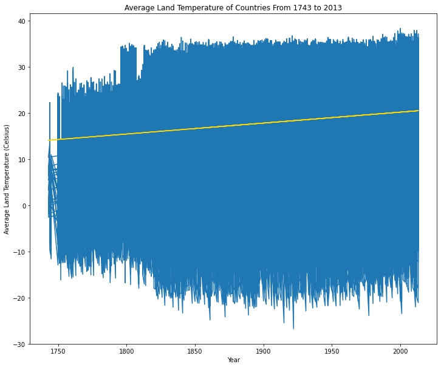

```python
# format the graph
plt.figure(figsize = (12,10))
plt.title("Average Land Temperature of Countries From 1743 to 2013")
plt.xlabel("Year")
plt.ylabel("Average Land Temperature (Celsius)")

# Create a linear regression line
x = df["Year"]
y = df["AverageTemperature"]
m, b = np.polyfit(x, y, 1)

#plot the data
plt.plot(x, y)
plt.plot(x, m * x + b, color = "gold")
plt.show()
```

This graph does not convey very much but we can see a slight positive trend and that there is a lot of variation. As such, we can explore this relationship further by looking at average temperature over time for different countries.

```python
temp = df

# Find each country's average temperature across all years
temp = temp.groupby(["Country"], as_index=False)[["AverageTemperature"]].mean()
temp.describe()
```

|  | AverageTemperature |
| --- | --- |
| count | 49.000000 |
| mean | 18.811186 |
| std | 7.204941 |
| min | 3.958878 |
| 25% | 12.571992 |
| 50% | 20.207842 |
| 75% | 25.809309 |
| max | 29.081291 |

As we suspect, the average temperature of countries vary quite alot, with the minimum average being around 3.959 degrees celsius and the maximum average being around 29.081. So, let's plot the average for each country.

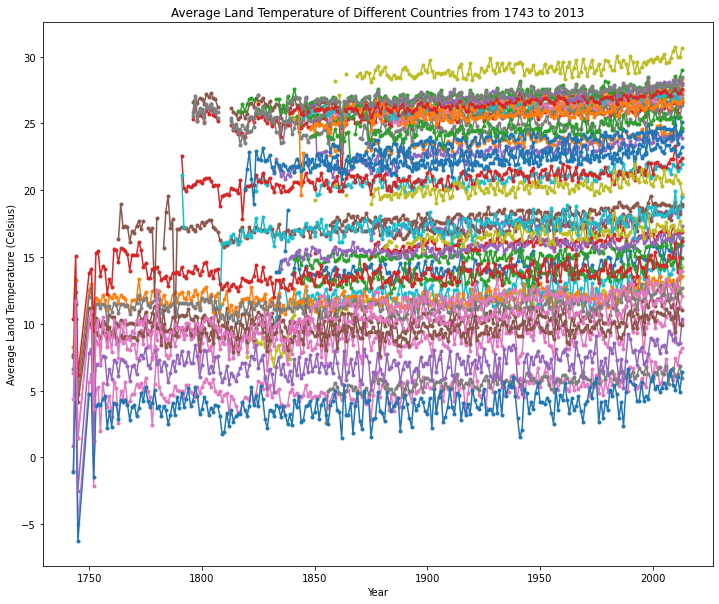

```python
temp = df

# Find each country's average temperature for each year
temp = temp.groupby(["Year","Country"], as_index=False)[["AverageTemperature"]].mean()


# Unmelt the data to more easily plot
temp1 = temp
temp_unmelt = temp1.pivot(index = "Year", columns = "Country").astype(float)

# Reattach year data
temp_unmelt["Year"] = temp.Year.unique()

# Format the graph
plt.figure(figsize = (12,10))
plt.title("Average Land Temperature of Different Countries from 1743 to 2013")
plt.xlabel("Year")
plt.ylabel("Average Land Temperature (Celsius)")

# Plot the data
for col in temp_unmelt.columns:
    if col != ("Year",""):
        plt.plot(temp_unmelt.loc[:,("Year","")], temp_unmelt.loc[:, col], marker = ".")
plt.show()
```

Again, we see that there is a slight upwards trend. Furthermore, there are a lot of missing data points for years before 1900. As such, we can elect to only look at data after 1900 to improve the distribution of our data. The down side of doing so is that we also neglect some of the data points that are before 1900. For the sake of exploring more meaningful data, however, this tradeoff is worth it.

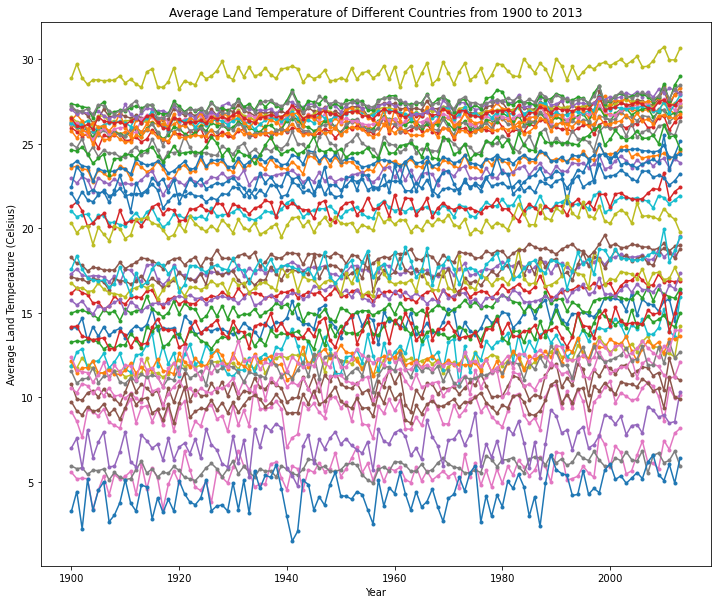

```python
df = df[df["Year"] >= 1900]
temp = df

temp = temp.groupby(["Year","Country"], as_index=False)[["AverageTemperature"]].mean()


# Unmelt the data to more easily plot
temp1 = temp
temp_unmelt = temp1.pivot(index = "Year", columns = "Country").astype(float)

# Reattach year data
temp_unmelt["Year"] = temp.Year.unique()

# Format the graph
plt.figure(figsize = (12,10))
plt.title("Average Land Temperature of Different Countries from 1900 to 2013")
plt.xlabel("Year")
plt.ylabel("Average Land Temperature (Celsius)")

# Plot the data
for col in temp_unmelt.columns:
    if col != ("Year",""):
        plt.plot(temp_unmelt.loc[:,("Year","")], temp_unmelt.loc[:, col], marker = ".")
plt.show()
```

Each line in this plot represents a different country. From this we see a better and cleaner correlation between average temperature and time. We do not see any obvious outliers since each line appears to be quite steady. Further, we notice that each country's datapoints bob up and down cyclically, which is something that we can continue explore later.

Lastly for this, we plot the mean average temperature of all major cities over time to demonstrate the idea that the central tendency is trending upwards.

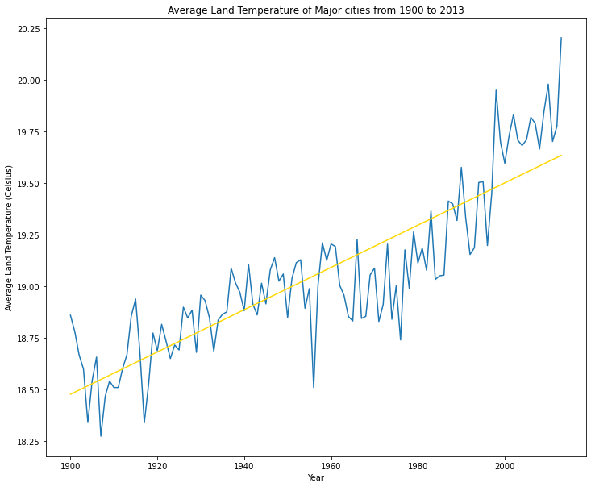

```python
# Get the mean of AverageTemperature over time
temp1 = temp1.groupby(["Year"]).mean()

# Get unqiue year values
temp1["Year"] = temp.Year.unique()

# Format the graph
plt.figure(figsize = (12,10))
plt.title("Average Land Temperature of Major cities from 1900 to 2013")
plt.xlabel("Year")
plt.ylabel("Average Land Temperature (Celsius)")

# Create a linear regression line
x = temp1["Year"]
y = temp1["AverageTemperature"]
m, b = np.polyfit(x, y, 1)

# Plot the data
plt.plot(x, y)
plt.plot(x, m * x + b, color = "gold")

plt.show()
```

We use the mean here instead of the other statistics because there does not appear to be outliers or skewness in the data set based on the previous graph and the data statistics. However, if there are some extreme outliers or if the data is highly skewed, choosing the mean as the representative central tendency may lead to less accurate plots. Learn more about summary statistics and distributions [here](https://cmsc320.github.io/2022spring/lecs/cmsc320_spr2022_lec10+11.pdf).

Another source of inspiration for data exploration is the [correlation matrix](https://pandas.pydata.org/docs/reference/api/pandas.DataFrame.corr.html). This matrix can help guide us by showing potential relationships.

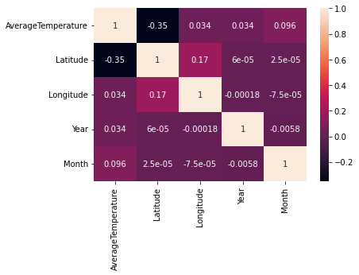

```python
temp = df

# Calculate correlation matrix
corr = temp.corr()

# Plot the heatmap
sns.heatmap(corr, xticklabels=corr.columns, yticklabels=corr.columns, annot=True)
```

This heatmap based on the correlation matrix demonstrate a negative correlation between latitude and average temperature. Let's investigate this further by mapping out the average temperatures at each location.

```python
temp = df

# Find each location's average temperature of each month of each year
temp = temp.groupby(["Latitude","Longitude"], as_index=False)[["AverageTemperature"]].mean()
colors = ["darkblue","blue","lightblue","lightred","red","darkred"]

# Discretize into 6 colors based on relative temperature
temp["color"] = pd.cut(temp["AverageTemperature"], bins=6, labels=colors)

# Create empty interactive world map
map_osm = folium.Map(location=[0,0], zoom_start=2)

# Place markers
for index, data in temp.iterrows():
    folium.Marker([data["Latitude"], data["Longitude"]], icon=folium.Icon(color=data["color"]), popup=data["AverageTemperature"]).add_to(map_osm)
map_osm
```

Make this Notebook Trusted to load map: File -> Trust Notebook

[interactive chart not shown]

The interactive map depicts the average temperature from 1900 to 2013 of different major cities across the world. The blue and red markers represent colder and warmer temperatures, respectively. The darker the color, the colder or warmer the average temperature. Click on them to see the specific values. Visually, the map is dominated by red markers near the equator whereas blue markers are more prevalant toward the poles. This indicates that there is indeed a relationship between average temperature and latitude.

Based on our previous finding, we decided to continue exploring this relationship between temperature and location. This time, we see the extent of temperature change from 1900 to 2013 at each major city.

```python
temp = df

# Group data by latitude, longitude, and year
temp = temp.groupby(["Latitude","Longitude","Year"], as_index=False)[["AverageTemperature"]].mean()

# Get the data for the years 1900 and 2013
temp = temp[temp.Year.isin([1900,2013])]
temp = temp.reset_index(drop=True)

temp.shape
```

```
(190, 4)
```

This process requires us to pay attention to what the data is like since we need specific pairs of data points and it might be that a city does not have data points for 1900 or 2013. However, it's always a good idea to keep track of the data you are using and outputting it to see if it makes sense. We currently have 190 data points, which suggests that there is a potentially valid pairing for each data point (since it's even). Next, we see if there are exactly 95 unique latitude and longitude positions.

```python
# Get unique locations
temp1 = temp.groupby(["Latitude","Longitude"], as_index=False).first()

# Only want latitude and longitude
temp1 = temp1.drop(["Year","AverageTemperature"], axis=1)

temp1
```

|  | Latitude | Longitude |
| --- | --- | --- |
| 0 | -37.78 | 144.41 |
| 1 | -34.56 | 151.78 |
| 2 | -32.95 | -69.89 |
| 3 | -32.95 | 18.19 |
| 4 | -29.74 | 31.38 |
| ... | ... | ... |
| 90 | 50.63 | 31.69 |
| 91 | 52.24 | -0.00 |
| 92 | 52.24 | 13.14 |
| 93 | 55.45 | 36.85 |
| 94 | 60.27 | 29.19 |

95 rows × 2 columns

There are 95 rows as we hoped, so we can be certain that each city has data for both years. Now we calculate the change in temperature from 1900 to 2013 for each city.

```python
temp1["Change"] = 0

# Calculate change in temperature for each city
for i, row in temp.iterrows():
    if i % 2 == 0:
        previous = temp.iloc[i]["AverageTemperature"]
    else:
        temp1.at[int(i/2),"Change"] = temp.iloc[i]["AverageTemperature"] - previous

temp1.describe()
```

|  | Latitude | Longitude | Change |
| --- | --- | --- | --- |
| count | 95.000000 | 95.000000 | 95.000000 |
| mean | 19.483684 | 43.862105 | 1.451479 |
| std | 22.902290 | 67.198539 | 0.902913 |
| min | -37.780000 | -118.700000 | -0.562500 |
| 25% | 5.630000 | 3.640000 | 0.862687 |
| 50% | 23.310000 | 45.000000 | 1.218500 |
| 75% | 36.170000 | 105.105000 | 1.940000 |
| max | 60.270000 | 151.780000 | 4.083667 |

From the above statistics, we see that most cities had an increase in average temperature. Let's visualize this on the world map.

```python
colors = ["white","lightred","red","darkred","purple","darkpurple"]

# Discretize into 6 colors based how much temperature has changed
temp1["color"] = pd.cut(temp1["Change"], bins=6, labels=colors)

# Create empty map
map_osm = folium.Map(location=[0,0], zoom_start=2)

# Place markers
for index, data in temp1.iterrows():
    folium.Marker([data["Latitude"], data["Longitude"]], icon=folium.Icon(color=data["color"]), popup=data["Change"]).add_to(map_osm)

map_osm
```

Make this Notebook Trusted to load map: File -> Trust Notebook

[interactive chart not shown]

The interactive map depicts the change in temperature from 1900 to 2013 of different major cities. The darker the marker, the greater the change is in the positive direction. Click on them to see the specific values. We see that change in temperature has been most drastic in specific countries and does not seem to be strongly correlated with position on the planet. This suggests that aspects of certain countries other than location makes cities more susceptible to global warming. Specifically, places that are more developed and industrialized seem to have experienced greater increases in temperature. As such, we can decide to move forward with a dataset that is grouped by countries, where the values for AverageTemperature are averages of the AverageTemperature of each countries' cities. The downside of doing so is that each city within a country have equal weight when the mean is computed even if one city has less population than the other. This allows cities with less population to have proportionally more influence. For our purposes, however, this a negligible side effect.

```python
df = df.groupby(["Country","Year","Month"], as_index=False)[["AverageTemperature"]].mean()
df.head()
```

|  | Country | Year | Month | AverageTemperature |
| --- | --- | --- | --- | --- |
| 0 | Afghanistan | 1900 | 1 | -1.217 |
| 1 | Afghanistan | 1900 | 2 | 2.293 |
| 2 | Afghanistan | 1900 | 3 | 10.578 |
| 3 | Afghanistan | 1900 | 4 | 12.428 |
| 4 | Afghanistan | 1900 | 5 | 19.992 |

Earlier, we discovered a cyclical pattern in the yearly temperature changes for each country. Let's explore that now. We group the data by country and month to see how average temperatures of each country change over the course of a year.

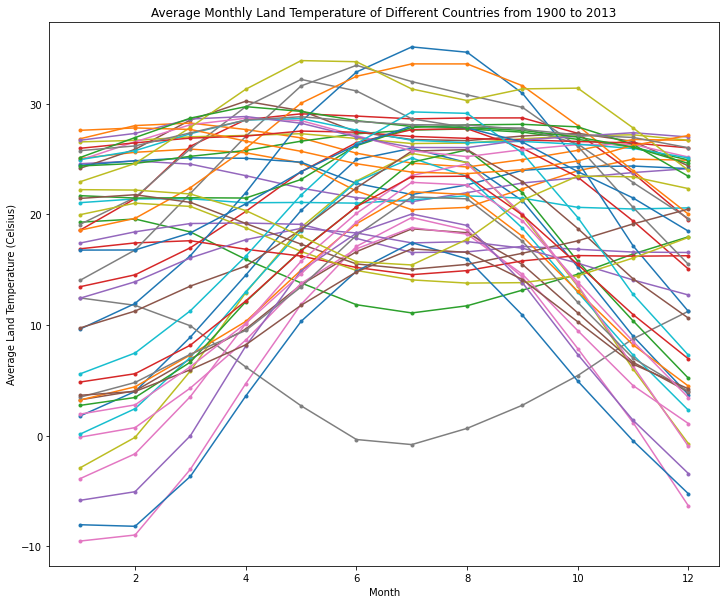

```python
# Groub by country and month
temp = df.groupby(["Country","Month"], as_index=False)[["AverageTemperature"]].mean()

# Unmelt the data to more easily plot
temp1 = temp
temp_unmelt = temp1.pivot(index = "Month", columns = "Country").astype(float)

# Reattach year data
temp_unmelt["Month"] = temp.Month.unique()

# Format the graph
plt.figure(figsize = (12,10))
plt.title("Average Monthly Land Temperature of Different Countries from 1900 to 2013")
plt.xlabel("Month")
plt.ylabel("Average Land Temperature (Celsius)")

# Plot the data
for col in temp_unmelt.columns:
    if col != ("Month",""):
        plt.plot(temp_unmelt.loc[:,("Month","")], temp_unmelt.loc[:, col], marker = ".")
plt.show()
```

Each line in this plot represents a different country. This plot suggests a signifcant correlation between month and temperature in different countries. Most cities seem to be colder during earlier months, peak during the middle of the year, and dropping again towards the end of the year. Other countries seem to experience the opposite in regards to temperature change. This makes sense since we know that climate condition change throughout the year differently for different areas of the world. This kind of seasonality in our dataset produces noise and will affect our analysis of the yearly temperature trends for each country. As such, we can decide to move forward with a dataset is grouped by years and no month variable. In this case, we average each country's monthly temperature to produce the AverageTemperature for the year.

```python
df = df.groupby(["Country","Year"], as_index=False)[["AverageTemperature"]].mean()
df
```

|  | Country | Year | AverageTemperature |
| --- | --- | --- | --- |
| 0 | Afghanistan | 1900 | 14.111417 |
| 1 | Afghanistan | 1901 | 14.114750 |
| 2 | Afghanistan | 1902 | 14.682917 |
| 3 | Afghanistan | 1903 | 13.345000 |
| 4 | Afghanistan | 1904 | 14.177750 |
| ... | ... | ... | ... |
| 5581 | Zimbabwe | 2009 | 20.523833 |
| 5582 | Zimbabwe | 2010 | 21.165833 |
| 5583 | Zimbabwe | 2011 | 20.781750 |
| 5584 | Zimbabwe | 2012 | 20.523333 |
| 5585 | Zimbabwe | 2013 | 19.756500 |

5586 rows × 3 columns

## Hypothesis Testing and Machine Learning Predictions

During hypothesis testing, we test the assumuptions we've made based on the exploratory data analysis. To test the likelihood that a hypothesis is true, we establish the mutually exclusive null and alternative hypotheses. The null hypothesis represents no change whereas the alternative hypothesis represents change. We compute the probability that a null hypothesis is true based on a p-Value. Learn more about the details [here](https://cmsc320.github.io/2022spring/lecs/cmsc320_spr2022_lec17.pdf). In this section, we will also use various machine learning algorithms to predict future temperature changes in various countries. Important technologies used: [statsmodels](https://www.statsmodels.org/stable/user-guide.html) , [sklearn](https://scikit-learn.org/stable/user_guide.html).

We first want to determine if there is indeed an upwards trend in global temperatures. From what we saw in the previous phase, let the null hypothesis be that there is no relationship between year and average temperature. We fit a linear regression model to determine the p-Value.

```python
import statsmodels.api as sm
from sklearn.linear_model import LinearRegression
from sklearn.model_selection import train_test_split
from sklearn.metrics import r2_score
from sklearn.metrics import mean_squared_error

# Fit a linear model with AverageTemperature as the response and Year as the predictor
lm = sm.OLS.from_formula("AverageTemperature ~ Year", df)
result = lm.fit()
result.summary()
```

OLS Regression Results

| Dep. Variable: | AverageTemperature | R-squared: | 0.002 |
| --- | --- | --- | --- |
| Model: | OLS | Adj. R-squared: | 0.002 |
| Method: | Least Squares | F-statistic: | 12.61 |
| Date: | Mon, 16 May 2022 | Prob (F-statistic): | 0.000388 |
| Time: | 15:05:49 | Log-Likelihood: | -18870. |
| No. Observations: | 5586 | AIC: | 3.774e+04 |
| Df Residuals: | 5584 | BIC: | 3.776e+04 |
| Df Model: | 1 |  |  |
| Covariance Type: | nonrobust |  |  |

|  | coef | std err | t | P>\|t\| | [0.025 | 0.975] |
| --- | --- | --- | --- | --- | --- | --- |
| Intercept | -0.9840 | 5.644 | -0.174 | 0.862 | -12.049 | 10.081 |
| Year | 0.0102 | 0.003 | 3.551 | 0.000 | 0.005 | 0.016 |

| Omnibus: | 2635.307 | Durbin-Watson: | 0.021 |
| --- | --- | --- | --- |
| Prob(Omnibus): | 0.000 | Jarque-Bera (JB): | 419.353 |
| Skew: | -0.373 | Prob(JB): | 8.68e-92 |
| Kurtosis: | 1.884 | Cond. No. | 1.16e+05 |

Notes:  
[1] Standard Errors assume that the covariance matrix of the errors is correctly specified.  
[2] The condition number is large, 1.16e+05. This might indicate that there are  
strong multicollinearity or other numerical problems.

We see that the p-Value (P>|t|) for Year is 0. This indicates that the likelyhood that the Year coefficient is measured by chance is 0%. In other words, there is a 0% chance that the Year variable has no affect on AverageTemperature, our dependent variable. As such, we can reject the null hypothesis. Moreover, we see by the coef value that global temperatures have been increasing by 0.0102 celsius every year since 1900. This suggests that since then, Earth's average land temperature has increased about 1.2444 celsius. Learn more about interpreting linear regression summaries [here](https://medium.com/swlh/interpreting-linear-regression-through-statsmodels-summary-4796d359035a).

```python
# Obtain independent varibles by themselves
x = df.drop(["AverageTemperature"], axis=1)

# Obtain dependent varible by itself
y = df["AverageTemperature"]

# Handle categorical independent variables
countries = pd.get_dummies(x, drop_first=True)
# Drop the extra columns
x = x.drop(["Country"], axis=1)
x = x.drop(["Year"], axis=1)
# Reattach the new variables
x = pd.concat([x,countries], axis=1)

# Split data into training and testing sets
x_train, x_test, y_train, y_test = train_test_split(x, y, test_size = 0.20, random_state = 4)

# Get the regression object and use it to fit the training data
LR = LinearRegression()
LR.fit(x_train,y_train)

# Feed the model the test data and retreive its outputs
y_prediction =  LR.predict(x_test)
R2 = r2_score(y_test,y_prediction)
print("R-squared: " + str(R2) )
```

```
R-squared: 0.9959873887639692
```

However, because our model uses multiple independent variables, we also need to look at its adjusted R-squared value. You can learn more about the differences between the two [here](https://medium.com/swlh/interpreting-linear-regression-through-statsmodels-summary-4796d359035a).

```python
# Calculate adjusted R2 based on its formula
# Sample size
n = .8 * 5586
# Number of independent variables
p = 2
AR2 = 1-(1-R2)*(n-1)/(n-p)
print("Adjusted R-squared: " + str(AR2))
```

```
Adjusted R-squared: 0.9959864904449856
```

We see that the adjusted R-squared value is still very high, which confirms the efficacy of our model. As such, we have obtained a model that can be used to predict future temperature changes based on location.

Let's see a summary of our model to gain more insight.

```python
# Add a column of ones
X_train = sm.add_constant(x_train)
lm = sm.OLS(y_train, X_train).fit()
lm.summary()
```

OLS Regression Results

| Dep. Variable: | AverageTemperature | R-squared: | 0.996 |
| --- | --- | --- | --- |
| Model: | OLS | Adj. R-squared: | 0.996 |
| Method: | Least Squares | F-statistic: | 2.228e+04 |
| Date: | Mon, 16 May 2022 | Prob (F-statistic): | 0.00 |
| Time: | 15:05:49 | Log-Likelihood: | -2784.8 |
| No. Observations: | 4468 | AIC: | 5670. |
| Df Residuals: | 4418 | BIC: | 5990. |
| Df Model: | 49 |  |  |
| Covariance Type: | nonrobust |  |  |

|  | coef | std err | t | P>\|t\| | [0.025 | 0.975] |
| --- | --- | --- | --- | --- | --- | --- |
| const | -5.5993 | 0.406 | -13.788 | 0.000 | -6.395 | -4.803 |
| Year | 0.0103 | 0.000 | 49.953 | 0.000 | 0.010 | 0.011 |
| Country_Angola | 9.3087 | 0.068 | 137.800 | 0.000 | 9.176 | 9.441 |
| Country_Australia | 0.7614 | 0.066 | 11.593 | 0.000 | 0.633 | 0.890 |
| Country_Bangladesh | 11.2327 | 0.067 | 168.738 | 0.000 | 11.102 | 11.363 |
| Country_Brazil | 8.6534 | 0.067 | 129.991 | 0.000 | 8.523 | 8.784 |
| Country_Burma | 12.4970 | 0.068 | 185.000 | 0.000 | 12.365 | 12.629 |
| Country_Canada | -8.8867 | 0.066 | -133.868 | 0.000 | -9.017 | -8.757 |
| Country_Chile | -8.6848 | 0.066 | -131.186 | 0.000 | -8.815 | -8.555 |
| Country_China | -2.3405 | 0.067 | -35.059 | 0.000 | -2.471 | -2.210 |
| Country_Colombia | 6.5480 | 0.066 | 99.176 | 0.000 | 6.419 | 6.677 |
| Country_Congo (Democratic Republic Of The) | 9.4457 | 0.068 | 139.825 | 0.000 | 9.313 | 9.578 |
| Country_Côte D'Ivoire | 11.8034 | 0.067 | 175.265 | 0.000 | 11.671 | 11.935 |
| Country_Dominican Republic | 11.6440 | 0.067 | 174.423 | 0.000 | 11.513 | 11.775 |
| Country_Egypt | 6.6866 | 0.066 | 101.275 | 0.000 | 6.557 | 6.816 |
| Country_Ethiopia | 3.0853 | 0.066 | 46.604 | 0.000 | 2.956 | 3.215 |
| Country_France | -3.8661 | 0.066 | -58.556 | 0.000 | -3.996 | -3.737 |
| Country_Germany | -5.3336 | 0.067 | -80.120 | 0.000 | -5.464 | -5.203 |
| Country_India | 11.5415 | 0.067 | 172.382 | 0.000 | 11.410 | 11.673 |
| Country_Indonesia | 12.2762 | 0.066 | 184.927 | 0.000 | 12.146 | 12.406 |
| Country_Iran | -1.7660 | 0.066 | -26.819 | 0.000 | -1.895 | -1.637 |
| Country_Iraq | 8.3678 | 0.068 | 122.319 | 0.000 | 8.234 | 8.502 |
| Country_Italy | -2.3186 | 0.067 | -34.631 | 0.000 | -2.450 | -2.187 |
| Country_Japan | -0.7022 | 0.068 | -10.299 | 0.000 | -0.836 | -0.569 |
| Country_Kenya | 1.6201 | 0.066 | 24.471 | 0.000 | 1.490 | 1.750 |
| Country_Mexico | 1.3924 | 0.066 | 20.975 | 0.000 | 1.262 | 1.523 |
| Country_Morocco | 2.8592 | 0.065 | 43.756 | 0.000 | 2.731 | 2.987 |
| Country_Nigeria | 12.0027 | 0.066 | 180.802 | 0.000 | 11.873 | 12.133 |
| Country_Pakistan | 10.4206 | 0.066 | 156.975 | 0.000 | 10.290 | 10.551 |
| Country_Peru | 2.2766 | 0.067 | 34.003 | 0.000 | 2.145 | 2.408 |
| Country_Philippines | 12.1115 | 0.066 | 182.946 | 0.000 | 11.982 | 12.241 |
| Country_Russia | -10.1570 | 0.067 | -152.578 | 0.000 | -10.287 | -10.026 |
| Country_Saudi Arabia | 12.0895 | 0.066 | 182.615 | 0.000 | 11.960 | 12.219 |
| Country_Senegal | 10.2240 | 0.066 | 154.850 | 0.000 | 10.095 | 10.353 |
| Country_Singapore | 12.1966 | 0.067 | 183.217 | 0.000 | 12.066 | 12.327 |
| Country_Somalia | 12.6823 | 0.066 | 193.596 | 0.000 | 12.554 | 12.811 |
| Country_South Africa | 3.8197 | 0.066 | 58.006 | 0.000 | 3.691 | 3.949 |
| Country_South Korea | -3.6544 | 0.068 | -53.764 | 0.000 | -3.788 | -3.521 |
| Country_Spain | -2.8496 | 0.065 | -43.719 | 0.000 | -2.977 | -2.722 |
| Country_Sudan | 14.6732 | 0.067 | 220.421 | 0.000 | 14.543 | 14.804 |
| Country_Syria | 3.1571 | 0.068 | 46.593 | 0.000 | 3.024 | 3.290 |
| Country_Taiwan | 7.8528 | 0.066 | 118.618 | 0.000 | 7.723 | 7.983 |
| Country_Tanzania | 11.2670 | 0.067 | 169.253 | 0.000 | 11.137 | 11.398 |
| Country_Thailand | 12.8823 | 0.067 | 192.415 | 0.000 | 12.751 | 13.014 |
| Country_Turkey | -0.5684 | 0.067 | -8.538 | 0.000 | -0.699 | -0.438 |
| Country_Ukraine | -7.1928 | 0.066 | -108.939 | 0.000 | -7.322 | -7.063 |
| Country_United Kingdom | -4.8259 | 0.067 | -72.495 | 0.000 | -4.956 | -4.695 |
| Country_United States | -2.3553 | 0.066 | -35.954 | 0.000 | -2.484 | -2.227 |
| Country_Vietnam | 12.8717 | 0.067 | 191.128 | 0.000 | 12.740 | 13.004 |
| Country_Zimbabwe | 5.7820 | 0.067 | 85.852 | 0.000 | 5.650 | 5.914 |

| Omnibus: | 259.114 | Durbin-Watson: | 2.008 |
| --- | --- | --- | --- |
| Prob(Omnibus): | 0.000 | Jarque-Bera (JB): | 1082.178 |
| Skew: | -0.059 | Prob(JB): | 1.02e-235 |
| Kurtosis: | 5.408 | Cond. No. | 1.18e+05 |

Notes:  
[1] Standard Errors assume that the covariance matrix of the errors is correctly specified.  
[2] The condition number is large, 1.18e+05. This might indicate that there are  
strong multicollinearity or other numerical problems.

Lets convert this summary to a data frame so we can produce more useful insights.

```python
results_as_html = lm.summary().tables[1].as_html()
results = pd.read_html(results_as_html, header=0, index_col=0)[0]
results.head()
```

|  | coef | std err | t | P>\|t\| | [0.025 | 0.975] |
| --- | --- | --- | --- | --- | --- | --- |
| const | -5.5993 | 0.406 | -13.788 | 0.0 | -6.395 | -4.803 |
| Year | 0.0103 | 0.000 | 49.953 | 0.0 | 0.010 | 0.011 |
| Country_Angola | 9.3087 | 0.068 | 137.800 | 0.0 | 9.176 | 9.441 |
| Country_Australia | 0.7614 | 0.066 | 11.593 | 0.0 | 0.633 | 0.890 |
| Country_Bangladesh | 11.2327 | 0.067 | 168.738 | 0.0 | 11.102 | 11.363 |

```python
results.describe()
```

|  | coef | std err | t | P>\|t\| | [0.025 | 0.975] |
| --- | --- | --- | --- | --- | --- | --- |
| count | 50.000000 | 50.000000 | 50.00000 | 50.0 | 50.000000 | 50.000000 |
| mean | 4.298842 | 0.072080 | 66.78900 | 0.0 | 4.157660 | 4.440080 |
| std | 7.222207 | 0.049105 | 106.52644 | 0.0 | 7.239651 | 7.206009 |
| min | -10.157000 | 0.000000 | -152.57800 | 0.0 | -10.287000 | -10.026000 |
| 25% | -2.180450 | 0.066000 | -23.56125 | 0.0 | -2.311250 | -2.049500 |
| 50% | 4.800850 | 0.067000 | 71.92900 | 0.0 | 4.670500 | 4.931500 |
| 75% | 11.472875 | 0.067000 | 171.59975 | 0.0 | 11.341750 | 11.604250 |
| max | 14.673200 | 0.406000 | 220.42100 | 0.0 | 14.543000 | 14.804000 |

## Insights

During this phase of the Data Science pipeline, we want to communicate what we have learned throughtout the analysis.  
The overall temperature of the Earth has been steadily increasing since the Industrial Revolution. Since 1900, average global temperatures have already risen by about 1.24 celsius. By the models we produced, we can expect to experience another overall temperature increase of 1.02 celsius in the next 100 years. This change in climate has the effect of disrupting ecosystems and bring about widespread extreme weather. Thus, it is in the best interest of all people and institutions to respond before irreversible damage is dealt.  
Based on what we have observed while analyzing the relationships between location and temperature change over time, we also learned that while most countries are experiencing an increase in temperatures, some are experiencing greater increases than others. Our analysis has shown that this is likely not because of location but some other factors that make certain countries more susceptible to global warming. As such, we can use the models we produced through machine learning to determine which countries are more at risk and help inform local measures to combat climate change.  
For further research, I suggest including socio-economic data for each country so that we might be able to better understand why countries experience differing levels of temperature change. Moreover, we can include statistics about the health of ecosystems over time in order to understand the impact that global warming has on Earth systems.